# DAB-501 Group Project 01 (Manik Shakya: w0786248, Yashu Bhati: w0784198)

Documentation of the dataset

```
Author/Collaborator: David Lapp (Owner)
Source Link : https://www.kaggle.com/datasets/johnsmith88/heart-disease-dataset
Data (CSV): https://www.kaggle.com/datasets/johnsmith88/heart-disease-dataset/download
```

Contribution to project: Manik and Yashu: We both contributed equally in this project. We discussed every aspect of the plot before plotting. We had a brief discussion about all the possible visualization we could make with our dataset. We each had our opinion about the plots. I helped her plotting the graphs where she needed help and she helped me to answer questions and datasets.

Loading all the needed libraries.

```r
library(tidyverse)
library(here)
library(ggpubr)
```

```r
packageVersion("tidyverse") # Version: 1.3.1
```

```
## [1] '1.3.1'
```

```r
packageVersion("ggplot2") # Version: 3.3.6
```

```
## [1] '3.3.6'
```

```r
packageVersion("ggpubr") # Version: 0.4.0
```

```
## [1] '0.4.0'
```

```r
# Read the dataset from the csv file
dataset <- read_csv("heart.csv")
# Print the number of rows and columns of dataset
dim(dataset)
```

```
## [1] 1025   14
```

```r
# Get the type of dataset
typeof(dataset)
```

```
## [1] "list"
```

```r
# Summary of the dataset
summary(dataset)
```

```
##       age             sex               cp            trestbps
##  Min.   :29.00   Min.   :0.0000   Min.   :0.0000   Min.   : 94.0
##  1st Qu.:48.00   1st Qu.:0.0000   1st Qu.:0.0000   1st Qu.:120.0
##  Median :56.00   Median :1.0000   Median :1.0000   Median :130.0
##  Mean   :54.43   Mean   :0.6956   Mean   :0.9424   Mean   :131.6
##  3rd Qu.:61.00   3rd Qu.:1.0000   3rd Qu.:2.0000   3rd Qu.:140.0
##  Max.   :77.00   Max.   :1.0000   Max.   :3.0000   Max.   :200.0
##       chol          fbs            restecg          thalach
##  Min.   :126   Min.   :0.0000   Min.   :0.0000   Min.   : 71.0
##  1st Qu.:211   1st Qu.:0.0000   1st Qu.:0.0000   1st Qu.:132.0
##  Median :240   Median :0.0000   Median :1.0000   Median :152.0
##  Mean   :246   Mean   :0.1493   Mean   :0.5298   Mean   :149.1
##  3rd Qu.:275   3rd Qu.:0.0000   3rd Qu.:1.0000   3rd Qu.:166.0
##  Max.   :564   Max.   :1.0000   Max.   :2.0000   Max.   :202.0
##      exang           oldpeak          slope             ca
##  Min.   :0.0000   Min.   :0.000   Min.   :0.000   Min.   :0.0000
##  1st Qu.:0.0000   1st Qu.:0.000   1st Qu.:1.000   1st Qu.:0.0000
##  Median :0.0000   Median :0.800   Median :1.000   Median :0.0000
##  Mean   :0.3366   Mean   :1.072   Mean   :1.385   Mean   :0.7541
##  3rd Qu.:1.0000   3rd Qu.:1.800   3rd Qu.:2.000   3rd Qu.:1.0000
##  Max.   :1.0000   Max.   :6.200   Max.   :2.000   Max.   :4.0000
##       thal           target
##  Min.   :0.000   Min.   :0.0000
##  1st Qu.:2.000   1st Qu.:0.0000
##  Median :2.000   Median :1.0000
##  Mean   :2.324   Mean   :0.5132
##  3rd Qu.:3.000   3rd Qu.:1.0000
##  Max.   :3.000   Max.   :1.0000
```

```r
# See the structure of the data
str(dataset)
```

```
## spec_tbl_df [1,025 × 14] (S3: spec_tbl_df/tbl_df/tbl/data.frame)
##  $ age     : num [1:1025] 52 53 70 61 62 58 58 55 46 54 ...
##  $ sex     : num [1:1025] 1 1 1 1 0 0 1 1 1 1 ...
##  $ cp      : num [1:1025] 0 0 0 0 0 0 0 0 0 0 ...
##  $ trestbps: num [1:1025] 125 140 145 148 138 100 114 160 120 122 ...
##  $ chol    : num [1:1025] 212 203 174 203 294 248 318 289 249 286 ...
##  $ fbs     : num [1:1025] 0 1 0 0 1 0 0 0 0 0 ...
##  $ restecg : num [1:1025] 1 0 1 1 1 0 2 0 0 0 ...
##  $ thalach : num [1:1025] 168 155 125 161 106 122 140 145 144 116 ...
##  $ exang   : num [1:1025] 0 1 1 0 0 0 0 1 0 1 ...
##  $ oldpeak : num [1:1025] 1 3.1 2.6 0 1.9 1 4.4 0.8 0.8 3.2 ...
##  $ slope   : num [1:1025] 2 0 0 2 1 1 0 1 2 1 ...
##  $ ca      : num [1:1025] 2 0 0 1 3 0 3 1 0 2 ...
##  $ thal    : num [1:1025] 3 3 3 3 2 2 1 3 3 2 ...
##  $ target  : num [1:1025] 0 0 0 0 0 1 0 0 0 0 ...
##  - attr(*, "spec")=
##   .. cols(
##   ..   age = col_double(),
##   ..   sex = col_double(),
##   ..   cp = col_double(),
##   ..   trestbps = col_double(),
##   ..   chol = col_double(),
##   ..   fbs = col_double(),
##   ..   restecg = col_double(),
##   ..   thalach = col_double(),
##   ..   exang = col_double(),
##   ..   oldpeak = col_double(),
##   ..   slope = col_double(),
##   ..   ca = col_double(),
##   ..   thal = col_double(),
##   ..   target = col_double()
##   .. )
##  - attr(*, "problems")=<externalptr>
```

```r
# Get the first 6 rows of data
head(dataset)
```

```
## # A tibble: 6 × 14
##     age   sex    cp trestbps  chol   fbs restecg thalach exang oldpeak slope
##   <dbl> <dbl> <dbl>    <dbl> <dbl> <dbl>   <dbl>   <dbl> <dbl>   <dbl> <dbl>
## 1    52     1     0      125   212     0       1     168     0     1       2
## 2    53     1     0      140   203     1       0     155     1     3.1     0
## 3    70     1     0      145   174     0       1     125     1     2.6     0
## 4    61     1     0      148   203     0       1     161     0     0       2
## 5    62     0     0      138   294     1       1     106     0     1.9     1
## 6    58     0     0      100   248     0       0     122     0     1       1
## # … with 3 more variables: ca <dbl>, thal <dbl>, target <dbl>
```

```r
# Get the last 6 rows of data
tail(dataset)
```

```
## # A tibble: 6 × 14
##     age   sex    cp trestbps  chol   fbs restecg thalach exang oldpeak slope
##   <dbl> <dbl> <dbl>    <dbl> <dbl> <dbl>   <dbl>   <dbl> <dbl>   <dbl> <dbl>
## 1    47     1     0      112   204     0       1     143     0     0.1     2
## 2    59     1     1      140   221     0       1     164     1     0       2
## 3    60     1     0      125   258     0       0     141     1     2.8     1
## 4    47     1     0      110   275     0       0     118     1     1       1
## 5    50     0     0      110   254     0       0     159     0     0       2
## 6    54     1     0      120   188     0       1     113     0     1.4     1
## # … with 3 more variables: ca <dbl>, thal <dbl>, target <dbl>
```

```r
# Adding a label for Sex. Human readable from number to string
sex_color <- factor(dataset$sex,levels = c(0, 1), labels=c("Male","Female"))
```

```r
# Get the age group of people's age
age_group <- cut(dataset$age, seq(0, 100, 10))
```

Two Plots displaying the distribution of a single continuous variable.

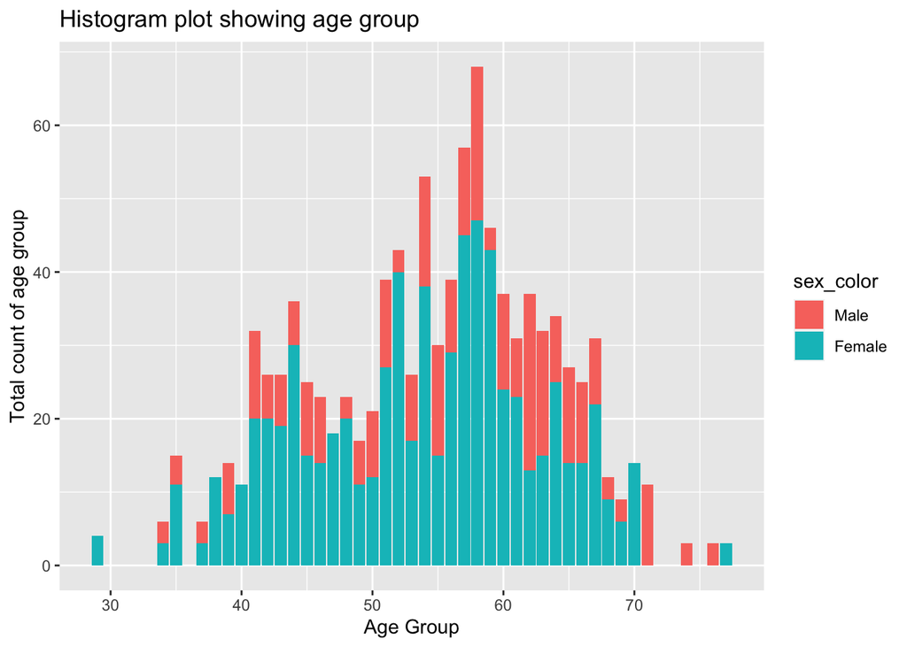

```r
# Plot for continuous variable.
# Plot show the are group on x-axis and total count on y-axis.
# Distinguished by color for Male and Female
ggplot(data = dataset, mapping = aes(x = age, fill=sex_color)) +
  geom_bar() +
  ggtitle("Histogram plot showing age group") +
  xlab("Age Group") +
  ylab("Total count of age group")
```

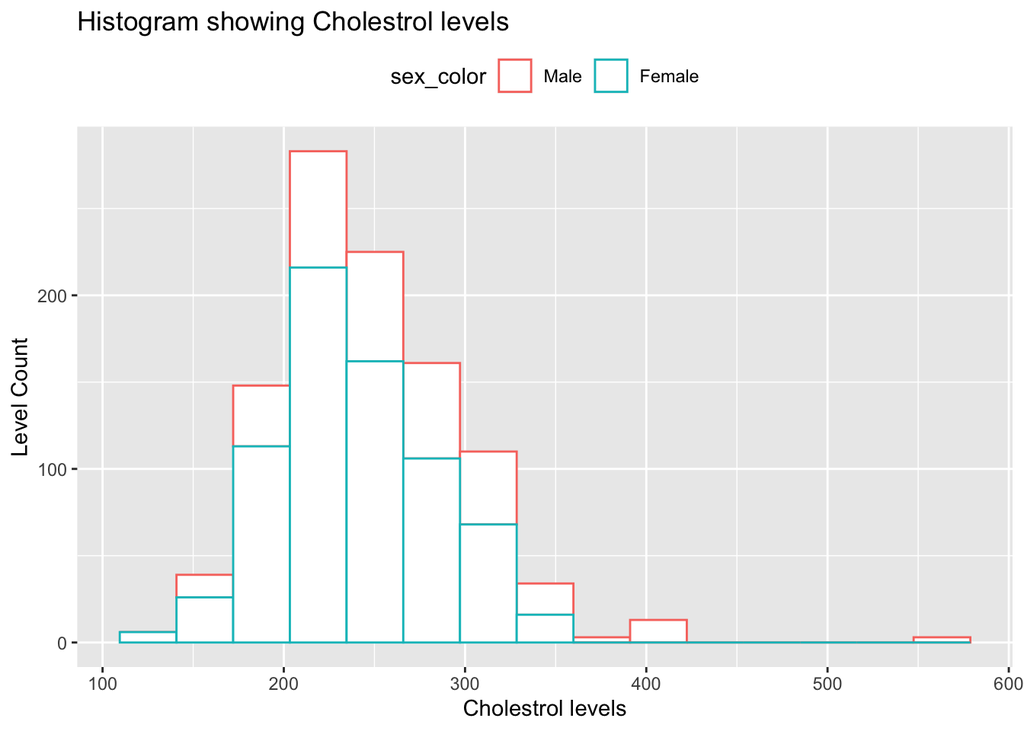

```r
# Plots for continuos variable
ggplot(data=dataset, mapping = aes(chol, colour = sex_color)) +
  geom_histogram(fill = "white",
                 bins = 15)  +
  ggtitle("Histogram showing Cholestrol levels") +
  xlab("Cholestrol levels") +
  ylab("Level Count") +
  theme(legend.position = "top")
```

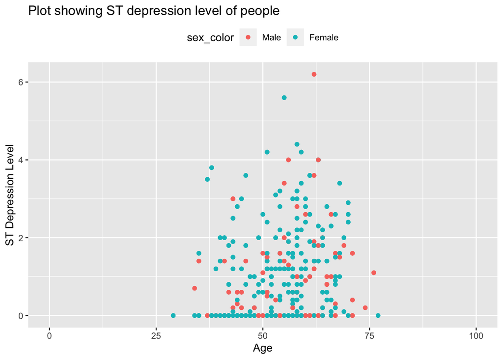

```r
# This plot shows age group of people with ST depression induced by exercise
ggplot(data=dataset, mapping = aes(x = age, y = oldpeak, colour = sex_color)) +
  geom_point() +
  scale_x_discrete(labels = c("0" = "Male", "1" = "Female")) +
  ggtitle("Plot showing ST depression level of people") +
  xlab("Age") +
  xlim(c(0, 100)) +
  ylab("ST Depression Level") +
  theme(legend.position = "top")
```